# DES_part2_03694565

## Programming Assignment - Part 2

### 2.7 Simulation Study

```python
import matplotlib
matplotlib.rcParams['figure.figsize'] = (20,15)
```

```python
import part2_simstudy
```

```
Queue Size = 5 Number of Runs = 1000 Sim.Time = 100000ms Mean waiting times = 1220.21041281 Mean Queue Length = 2.38600787 Variance = 96345.1859992
Queue Size = 6 Number of Runs = 1000 Sim.Time = 100000ms Mean waiting times = 1475.38986792 Mean Queue Length = 2.8991697 Variance = 169261.125225
```

```
Queue Size = 7 Number of Runs = 1000 Sim.Time = 100000ms Mean waiting times = 1684.21576419 Mean Queue Length = 3.32091502 Variance = 271615.024141
```

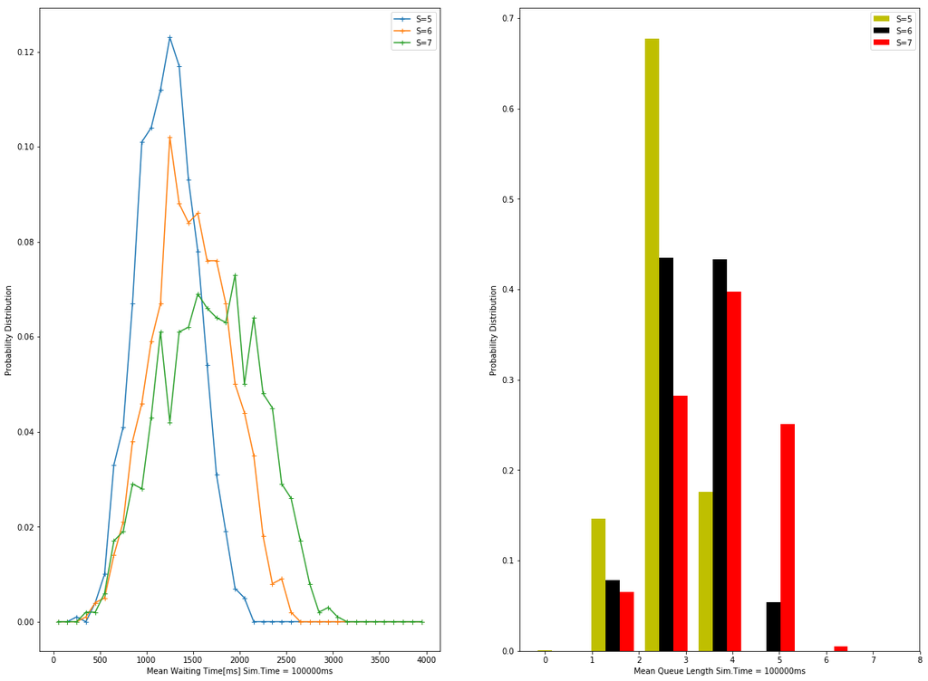

```python
part2_simstudy.task_2_7_1()
```

```
Queue Size = 5 Number of Runs = 1000 Sim.Time = 1000000ms Mean waiting times = 1335.68142655 Mean Queue Length = 2.606178608 Variance = 11201.3576227
Queue Size = 6 Number of Runs = 1000 Sim.Time = 1000000ms Mean waiting times = 1631.87380586 Mean Queue Length = 3.201210956 Variance = 20209.874498
```

```
Queue Size = 7 Number of Runs = 1000 Sim.Time = 1000000ms Mean waiting times = 1947.27029058 Mean Queue Length = 3.832337781 Variance = 37011.9713091
```

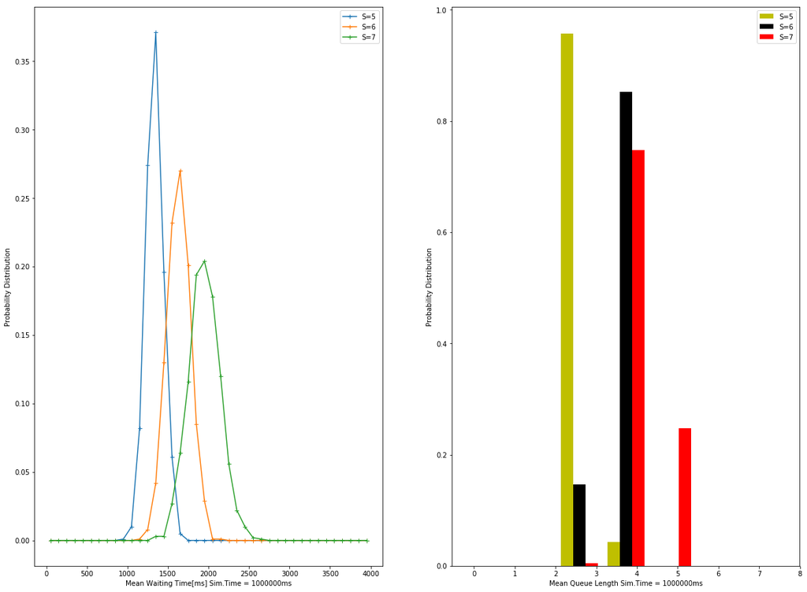

```python
part2_simstudy.task_2_7_2()
```

### 2.8 Analysis and General Questions

#### **Task 2.8.1:** Systems with Different Queue Capacity

- Mean waiting time and mean queue length increases in both 100s and 1000s scenario when the queue length increases. It can be said that variance also increases with increasing queue length. Also, as it can be seen from two different graphs, variance becomes smaller with longer simulations.
- Lower variance can be explained with the transient phase of the system as described in the law 9.2. When the simulation runs longer, then it can eliminate the effect of transient state and give more precise result.
- Mean waiting time is also increasing with longer simulations. This can also be explained with the transient phase effect. When we average the waiting time of a system within smaller simulation time, then we get more samples from transient phase which has lower waiting time than true mean. Thus, mean waiting time will become lower than longer simulation runs.

#### Task 2.8.2: Choosing the right number of bins

- To answer this question, I should first explain what bins mean: Bins parameter tells me how many bins my data will be divided into. So, If the bins are low, then all the data will gather in same spot which will make it difficult to observe the behaviour of the data. If it is so high, then there will be so many peaks in the graph which make it hard to find the distribution. There are different rules (e.g. the Freedman-Diaconis Rule, Sturges' Rule, Scott's Rule, etc.) explaining how to choose bins.

#### Task 2.8.3: Variance Calculation

- As mentioned in task 2.3.1, when we have limited number of samples we have to divide *(n-1)* instead of *n* where n is the number of observations. This method correct the bias in the estimation which is called in the literature as Bessel's correction. If we just use *n* to calcucalte sample variance, then our estimator will be biased for limited number of samples. In order to have unbiased estimater, we should divide *(n-1)*. If we have infinite samples, then we can use *n*.